# Netwok Analysis Project

# Netwok Analysis Project

The Star Wars social network

Eloy Pérez Gómez, Álvaro Novillo Correas & Jorge Sánchez Polo

2023-05-17

## Part 1

**1) Explain the network including which vertices and edges form it, as well as any additional attributes that may form the network, its vertices and/or its edges.**

We are going to study a Star Wars social network (this network was downloaded from kaggle at https://www.kaggle.com/datasets/ruchi798/star-wars). The nodes of this network are the characters of the first seven films and they are connected if they speak with each other in the same scene (this corresponds to the file “starwars-full-interactions-allCharacters-merged.json” from the downloaded data).

The original network has the following elements:

- The nodes have the following properties:
  - name: Name of the character
  - value: Number of scenes the character appeared in
  - colour: Color in the visualization
- Links represent connections between characters:
  - source: zero-based index of the character that is one end of the link, the order of nodes is the order in which they are listed in the “nodes” element
  - target: zero-based index of the character that is the the other end of the link.
  - value: Number of scenes where the “source character” and “target character” of the link appeared together.

We modify this network and add the following attributes:

- name.real: Contains the name of each character (a copy of the previous attribute “name”).
- name: a zero-based index for each character.
- colour: we have modified the color of some of the characters.
- role: we introdue anew attribute that separates the characters in main villains (letter “v”), heroes (letter “h”) or background characters (letter “b”).

```r
# Set the directory path where the JSON files are located
directory_path <- "data" #CHANGE IT WITH YOUR DATA PATH
# Get the list of all JSON files in the directory
json_files <- list.files(path = directory_path, pattern = "*.json", full.names = TRUE)
# Choose the desired JSON file
desired_file <- json_files[22]
# Load the JSON file into R
json_data <- fromJSON(desired_file)
```

Access the nodes and edges (the “nodes.xlsx” file contains the modified version of the nodes)

```r
nodes <- read.xlsx("nodes.xlsx")
edges <- json_data$links
```

**2) Describe what the analysis of such a network may be of interest. That is, what are the points that make the network of interest to a general audience.**

Star wars is a franchise most of us grew up watching, either the original trilogy or the later releases. The study of a social network composed of the Star wars characters and their relations may not be as important as some networks related with medicine applications or industry, but it is worth taking a look at, even if it is just for the sake of our childhood memories.

**3) Make a first graph of the network and describe the main characteristics including whether the network is directed or undirected, if there are subnetworks that may be of interest, if there are loops and/or multi-edges, etc.**

Create a graph from the data

```r
network <- graph_from_data_frame(edges, vertices = nodes, directed = FALSE)
E(network)$weight <- edges$value
```

```r
# Set the color of each node
V(network)$color <- nodes$colour
# Set the label of each node
V(network)$label <- nodes$name
# Set role attribute of each node
V(network)$role <- nodes$role
V(network)$name = nodes$name.real
```

Plot the graph

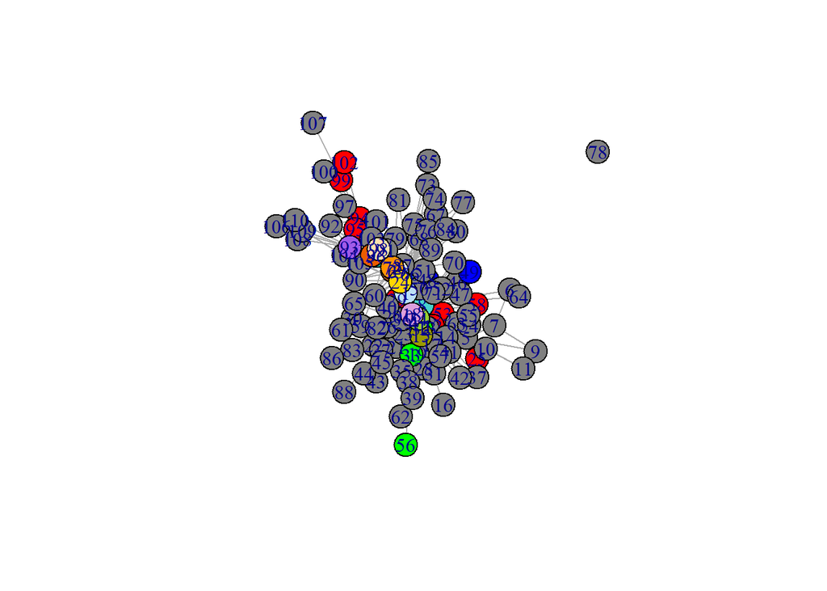

```r
A = as_adjacency_matrix(network, attr="weight")
plot(network)
```

We have an undirected, weighted network. There are not any loops or multi-edges.

We have several interesting subnetworks. We are going to divide the network in two ways: first using the attributes of the nodes, i.e., considering the most relevant nodes in terms of weights and number of appearances; the second method for obtaining subnetworks is going to be using the information we have from the films. We are going to separate in a network for “heroes” and a network for “villains”.

We are going to define three subnetworks depending on the weight of the characters and two subnetworks that contain the main villains and the heroes.

```r
subnetwork1 <- subgraph.edges(network, E(network)[E(network)$weight>max(E(network)$weight)*0.5])
subnetwork2 <- subgraph.edges(network, E(network)[E(network)$weight>max(E(network)$weight)*0.3])
subnetwork3 <- subgraph.edges(network, E(network)[E(network)$weight>max(E(network)$weight)*0.2])
Siths_network <- delete.vertices(network, V(network)[V(network)$role != 'v'])
Heroes_network <- delete.vertices(network, V(network)[V(network)$role != 'h'])
```

**4) Compute the order and size of the network and certain induced subnetworks of interest and draw conclusions about these values. If the network is directed, repeat the operation for in, out and total.**

[figure not shown]

```r
adj_matrix <- as_adjacency_matrix(network,attr = "weight",sparse = T)

# Set the row and column names of the matrix to the node names
rownames(adj_matrix) <- nodes$name.real
colnames(adj_matrix) <- nodes$name.real

# Plot the matrix
library(corrplot)
corrplot(as.matrix(adj_matrix),  method = 'shade',is.corr = FALSE,col.lim = c(0,max(max(as.matrix(adj_matrix)))), order = 'AOE', diag = FALSE, tl.cex = 0.3,col = COL1('YlOrBr', 10),tl.col = 'black')
```

Upon inspecting the adjacency matrix, we observed that certain characters such as Darth Vader, Han Solo, and Chewbacca had the highest number of interactions with other characters. These characters had the most weighted links, indicating a significant amount of interaction with other characters in the network.

```r
top_nodes <- nodes[order(nodes$value, decreasing = TRUE),][1:10,]

print(top_nodes)
```

```
##     name value  colour   name.real role
## 1      0   190 #FF0000 DARTH VADER    v
## 105    1   171 #bde0f6       R2-D2    h
## 109   72   170 #ff9400         HAN    h
## 15    66   161 #3881e5        LUKE    h
## 110   24   151 #FFD700       C-3PO    h
## 16     8   148 #48D1CC     OBI-WAN    h
## 103    2   145 #A0522D   CHEWBACCA    h
## 106   69    99 #DCDCDC        LEIA    h
## 107   18    75 #DDA0DD       PADME    h
## 13    96    64 #07b19f        FINN    h
```

[figure not shown]

```r
# Create a barplot using 'name.real' as labels and 'value' as heights
barplot(top_nodes$value,
        names.arg = top_nodes$name.real,
        main = "Top Characters with the highest screenplay",
        ylab = "Screenplay",
        col = "steelblue",
        las=2)
```

The resulting plot shows that the characters with the highest total screenplay are the main characters of the saga (as expected), and also have a high number of interactions with other characters in the network.

After this initial inspection, the general properties of the network (order, size, and average degree) are:

```r
cat("Order of the network:", gorder(network), "\n")
```

```
## Order of the network: 111
```

```r
cat("Size of the network:", gsize(network), "\n")
```

```
## Size of the network: 444
```

```r
cat("Average degree:", mean(degree(network)), "\n")
```

```
## Average degree: 8
```

In the case of the previously defined subnetworks, we have:

- Order:

```
## Order of the network that contains the top 50% characters: 9
```

```
## Order of the network that contains the top 70% characters: 12
```

```
## Order of the network that contains the top 80% characters: 18
```

```
## Order of the network that contains the main villains: 13
```

```
## Order of the network that contains the heroes: 22
```

- Size:

```
## Size of the network that contains the top 50% characters: 10
```

```
## Size of the network that contains the top 70% characters: 19
```

```
## Size of the network that contains the top 80% characters: 34
```

```
## Size of the network that contains the main villains: 15
```

```
## Size of the network that contains the heroes: 100
```

We observe that as the number of characters included rises (which means an increase in the order), the size of the subnetworks grows as well. Regarding the sith and heroes subnetworks, we observe that while they both have a kind-of similar order, the size is much larger for the heroes

**5) Obtain the degree distribution with and without weights (if any) and comment on the results obtained. Again, if the network is directed, repeat the operation for in, out and total.**